# Digital literacy: Watch / engagement diagnostics

**Purpose.** Self-contained checks on prepared `wave_9` / `wave_10` outputs from `1_data_prep.qmd`. Focus: short- vs long-term **watch → like** (and related watch / skip / report) distributions, scales, and sample sizes that feed `fig_watch_like_short_long` and companions in `2_analysis.qmd`. Not causal; run after data prep.

# 1 Setup

```r
pacman::p_load(tidyverse, knitr, scales)

treat_cols <- c(Control = "#4C78A8", Treatment = "#E45756")

strategies_art <- c(
  "political\n(emotional)",
  "political\n(neutral)",
  "entertainment"
)

horizon_levels <- c("Short-term (wave 9)", "Long-term (wave 10)")
```

# 2 Data (same prepared outputs as analysis)

```r
wave_9  <- read_rds("data/wave_9.rds")
wave_10 <- read_rds("data/wave_10.rds")

datasets <- list(
  `Short-term (wave 9)` = wave_9,
  `Long-term (wave 10)` = wave_10
)

prep_row <- function(dat, horizon) {
  dat |>
    filter(strategy_2 %in% strategies_art) |>
    transmute(
      ID = as.character(ID),
      strategy = factor(as.character(strategy_2), levels = strategies_art),
      treatment = factor(
        ifelse(workshop_Treatment == 1, "Treatment", "Control"),
        levels = c("Control", "Treatment")
      ),
      watch = as.numeric(watch_percentage_),
      watchtime = as.numeric(watchtime_video_),
      duration = as.numeric(duration_video_),
      like = as.numeric(videoLikep1r),
      report = as.numeric(videoCommentTickedp1r),
      bookmark = as.numeric(videoBookmarkp1r),
      skip = as.numeric(skipped_video_),
      horizon = factor(horizon, levels = horizon_levels)
    )
}

df <- bind_rows(
  prep_row(wave_9, "Short-term (wave 9)"),
  prep_row(wave_10, "Long-term (wave 10)")
)
```

# 3 Variable names and scales

Printed checks for the columns used in watch–like / watch–report figures.

```r
scale_check <- function(dat, lab) {
  wp <- as.numeric(dat$watch_percentage_)
  wt <- as.numeric(dat$watchtime_video_)
  dur <- as.numeric(dat$duration_video_)
  ratio <- wt / dur
  ok <- is.finite(wp) & is.finite(ratio)
  tibble(
    wave = lab,
    n_rows = nrow(dat),
    n_id = n_distinct(dat$ID),
    watch_var = "watch_percentage_",
    like_var = "videoLikep1r",
    report_var = "videoCommentTickedp1r",
    skip_var = "skipped_video_",
    watch_min = min(wp, na.rm = TRUE),
    watch_max = max(wp, na.rm = TRUE),
    watch_mean = mean(wp, na.rm = TRUE),
    watch_median = median(wp, na.rm = TRUE),
    n_na_watch = sum(is.na(wp)),
    share_na_watch = mean(is.na(wp)),
    n_exact0 = sum(wp == 0, na.rm = TRUE),
    share_exact0_among_nonNA = mean(wp == 0, na.rm = TRUE),
    n_gt1 = sum(wp > 1, na.rm = TRUE),
    n_gt100 = sum(wp > 100, na.rm = TRUE),
    cor_wp_vs_wt_over_dur = if (sum(ok) > 2) cor(wp[ok], ratio[ok]) else NA_real_,
    mean_abs_wp_minus_ratio = if (sum(ok) > 0) mean(abs(wp[ok] - ratio[ok])) else NA_real_,
    skip_mean = mean(as.numeric(dat$skipped_video_), na.rm = TRUE),
    like_mean = mean(as.numeric(dat$videoLikep1r), na.rm = TRUE),
    report_mean = mean(as.numeric(dat$videoCommentTickedp1r), na.rm = TRUE)
  )
}

scale_tbl <- bind_rows(
  scale_check(wave_9, "wave_9"),
  scale_check(wave_10, "wave_10")
)

scale_tbl |>
  mutate(across(where(is.numeric), ~ round(.x, 4))) |>
  kable(caption = "Scale / completeness: watch_percentage_ should be share of duration on [0, 1] (= watchtime/duration).")
```

Scale / completeness: watch_percentage_ should be share of duration on [0, 1] (= watchtime/duration).

| wave | n_rows | n_id | watch_var | like_var | report_var | skip_var | watch_min | watch_max | watch_mean | watch_median | n_na_watch | share_na_watch | n_exact0 | share_exact0_among_nonNA | n_gt1 | n_gt100 | cor_wp_vs_wt_over_dur | mean_abs_wp_minus_ratio | skip_mean | like_mean | report_mean |
| --- | --- | --- | --- | --- | --- | --- | --- | --- | --- | --- | --- | --- | --- | --- | --- | --- | --- | --- | --- | --- | --- |
| wave_9 | 132954 | 4436 | watch_percentage_ | videoLikep1r | videoCommentTickedp1r | skipped_video_ | 0 | 1 | 0.3984 | 0.25 | 10 | 0.0001 | 13139 | 0.0988 | 0 | 0 | 1 | 0 | 0.7896 | 0.0936 | 0.0178 |
| wave_10 | 121880 | 3359 | watch_percentage_ | videoLikep1r | videoCommentTickedp1r | skipped_video_ | 0 | 1 | 0.0294 | 0.00 | 67155 | 0.5510 | 51301 | 0.9374 | 0 | 0 | 1 | 0 | 0.9856 | 0.0871 | 0.0152 |

```r
cat(
  "\nInterpretation:\n",
  "- Axis label in analysis figures ('share of video duration') matches the 0–1 scale.\n",
  "- Not seconds; not 0–100 percent.\n",
  "- Figure chunks filter is.finite(watch) (drop NA); they do not coerce NA → 0.\n",
  sep = ""
)
```

```
Interpretation:
- Axis label in analysis figures ('share of video duration') matches the 0–1 scale.
- Not seconds; not 0–100 percent.
- Figure chunks filter is.finite(watch) (drop NA); they do not coerce NA → 0.
```

# 4 n by facet (type × treatment × wave)

```r
n_facet <- df |>
  summarise(
    n_rows = n(),
    n_id = n_distinct(ID),
    n_finite_watch = sum(is.finite(watch)),
    n_finite_watch_like = sum(is.finite(watch) & is.finite(like)),
    .by = c(horizon, strategy, treatment)
  ) |>
  arrange(horizon, strategy, treatment)

n_facet |> kable(caption = "Row and ID counts by type × treatment × wave (all prepared rows in article strategy set).")
```

Row and ID counts by type × treatment × wave (all prepared rows in article strategy set).

[output not shown]

# 5 Watch distributions by wave

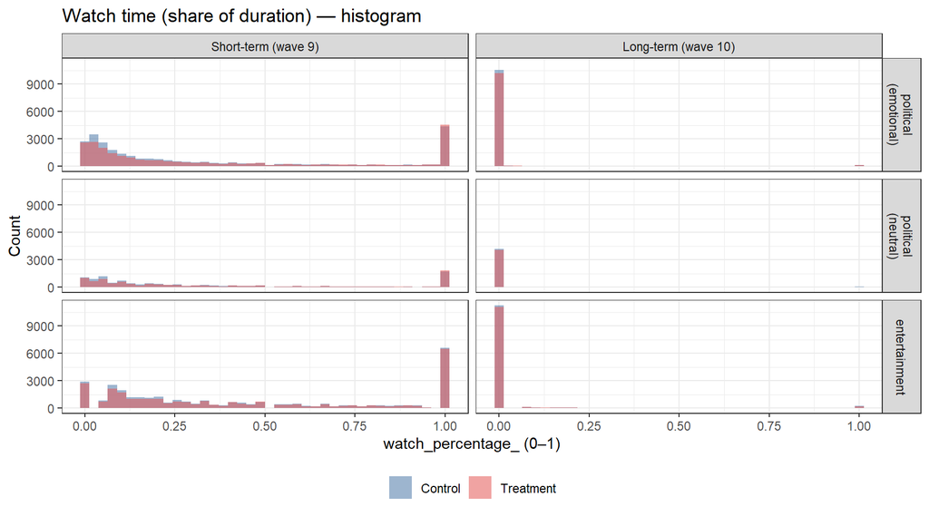

```r
df_watch <- df |> filter(is.finite(watch))

ggplot(df_watch, aes(x = watch, fill = treatment)) +
  geom_histogram(bins = 40, alpha = 0.55, position = "identity") +
  scale_fill_manual(values = treat_cols) +
  facet_grid(cols = vars(horizon), rows = vars(strategy)) +
  labs(
    title = "Watch time (share of duration) — histogram",
    x = "watch_percentage_ (0–1)",
    y = "Count",
    fill = NULL
  ) +
  theme_bw(base_size = 11) +
  theme(legend.position = "bottom")
```

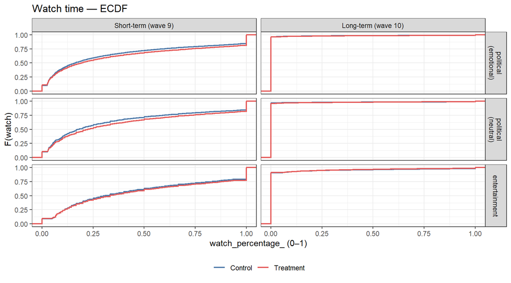

```r
ggplot(df_watch, aes(x = watch, color = treatment)) +
  stat_ecdf(linewidth = 0.8) +
  scale_color_manual(values = treat_cols) +
  facet_grid(cols = vars(horizon), rows = vars(strategy)) +
  labs(
    title = "Watch time — ECDF",
    x = "watch_percentage_ (0–1)",
    y = "F(watch)",
    color = NULL
  ) +
  theme_bw(base_size = 11) +
  theme(legend.position = "bottom")
```

```r
df |>
  summarise(
    n = n(),
    share_na_watch = mean(is.na(watch)),
    share_exact0_all_rows = mean(!is.na(watch) & watch == 0),
    share_exact0_among_nonNA = mean(watch == 0, na.rm = TRUE),
    mean_watch = mean(watch, na.rm = TRUE),
    median_watch = median(watch, na.rm = TRUE),
    .by = c(horizon, treatment)
  ) |>
  mutate(across(where(is.numeric), ~ round(.x, 4))) |>
  kable(caption = "NA and exact-zero shares for watch by wave × treatment.")
```

NA and exact-zero shares for watch by wave × treatment.

| horizon | treatment | n | share_na_watch | share_exact0_all_rows | share_exact0_among_nonNA | mean_watch | median_watch |
| --- | --- | --- | --- | --- | --- | --- | --- |
| Short-term (wave 9) | Control | 70272 | 0.0001 | 0.0961 | 0.0961 | 0.3857 | 0.2222 |
| Short-term (wave 9) | Treatment | 62682 | 0.0001 | 0.1019 | 0.1019 | 0.4126 | 0.2632 |
| Long-term (wave 10) | Treatment | 60355 | 0.5521 | 0.4195 | 0.9366 | 0.0289 | 0.0000 |
| Long-term (wave 10) | Control | 61525 | 0.5499 | 0.4223 | 0.9383 | 0.0299 | 0.0000 |

# 6 Like / report by wave

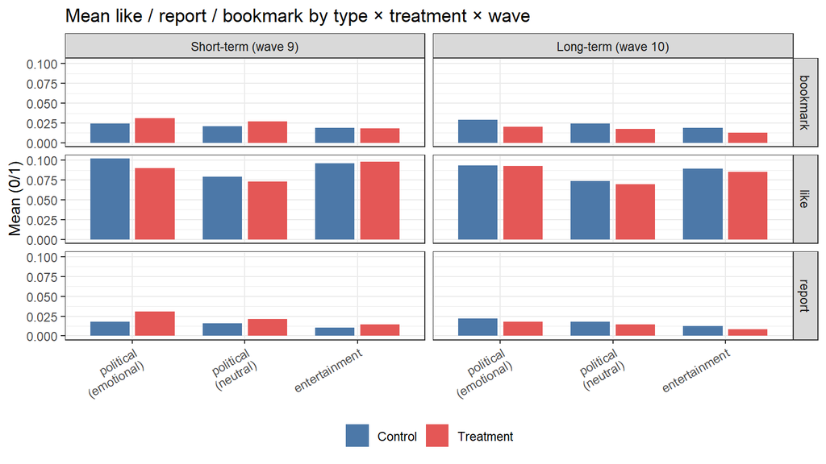

```r
eng_means <- df |>
  summarise(
    like = mean(like, na.rm = TRUE),
    report = mean(report, na.rm = TRUE),
    bookmark = mean(bookmark, na.rm = TRUE),
    n = n(),
    .by = c(horizon, strategy, treatment)
  ) |>
  pivot_longer(c(like, report, bookmark), names_to = "outcome", values_to = "mean")

ggplot(eng_means, aes(x = strategy, y = mean, fill = treatment)) +
  geom_col(position = position_dodge(width = 0.8), width = 0.7) +
  scale_fill_manual(values = treat_cols) +
  facet_grid(rows = vars(outcome), cols = vars(horizon)) +
  labs(
    title = "Mean like / report / bookmark by type × treatment × wave",
    x = NULL,
    y = "Mean (0/1)",
    fill = NULL
  ) +
  theme_bw(base_size = 11) +
  theme(
    axis.text.x = element_text(angle = 30, hjust = 1),
    legend.position = "bottom"
  )
```

```r
eng_means |>
  mutate(mean = round(mean, 4)) |>
  kable()
```

[output not shown]

# 7 Skip rates and E(watch | not skip)

```r
skip_tbl <- df |>
  summarise(
    n = n(),
    share_na_skip = mean(is.na(skip)),
    skip_rate = mean(skip, na.rm = TRUE),
    mean_watch = mean(watch, na.rm = TRUE),
    mean_watch_if_not_skip = mean(watch[skip == 0], na.rm = TRUE),
    mean_watch_if_skip = mean(watch[skip == 1], na.rm = TRUE),
    n_not_skip = sum(skip == 0, na.rm = TRUE),
    .by = c(horizon, treatment)
  )

skip_tbl |>
  mutate(across(where(is.numeric), ~ round(.x, 4))) |>
  kable(caption = "Skip rates and conditional mean watch.")
```

Skip rates and conditional mean watch.

| horizon | treatment | n | share_na_skip | skip_rate | mean_watch | mean_watch_if_not_skip | mean_watch_if_skip | n_not_skip |
| --- | --- | --- | --- | --- | --- | --- | --- | --- |
| Short-term (wave 9) | Control | 70272 | 0.0001 | 0.8019 | 0.3857 | 0.9946 | 0.2352 | 13923 |
| Short-term (wave 9) | Treatment | 62682 | 0.0001 | 0.7759 | 0.4126 | 0.9951 | 0.2444 | 14045 |
| Long-term (wave 10) | Treatment | 60355 | 0.5527 | 0.9867 | 0.0289 | 1.0000 | 0.0145 | 358 |
| Long-term (wave 10) | Control | 61525 | 0.5505 | 0.9844 | 0.0299 | 1.0000 | 0.0134 | 431 |

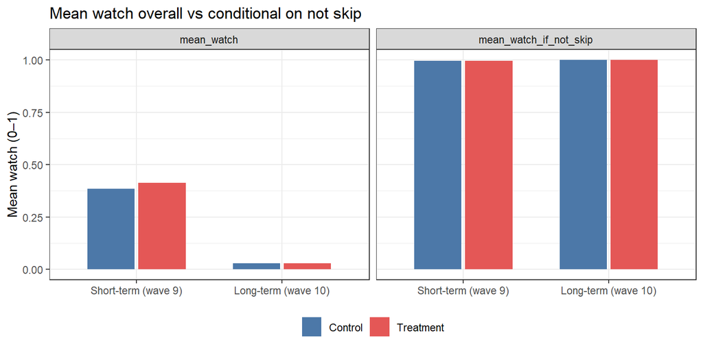

```r
ggplot(
  skip_tbl |>
    select(horizon, treatment, mean_watch, mean_watch_if_not_skip) |>
    pivot_longer(-c(horizon, treatment), names_to = "which", values_to = "mean_watch"),
  aes(x = horizon, y = mean_watch, fill = treatment)
) +
  geom_col(position = position_dodge(width = 0.7), width = 0.65) +
  scale_fill_manual(values = treat_cols) +
  facet_wrap(~which, ncol = 2) +
  labs(
    title = "Mean watch overall vs conditional on not skip",
    x = NULL,
    y = "Mean watch (0–1)",
    fill = NULL
  ) +
  theme_bw(base_size = 11) +
  theme(legend.position = "bottom")
```

# 8 cor(watch, like) overall and conditional on watch > 0.05 / 0.1

```r
cor_block <- function(dat, label) {
  tibble(
    sample = label,
    n = nrow(dat),
    cor_watch_like = cor(dat$watch, dat$like, use = "complete.obs"),
    cor_watch_report = cor(dat$watch, dat$report, use = "complete.obs"),
    mean_watch = mean(dat$watch, na.rm = TRUE),
    mean_like = mean(dat$like, na.rm = TRUE)
  )
}

cor_tbl <- df |>
  filter(is.finite(watch), is.finite(like), is.finite(report)) |>
  group_by(horizon, treatment) |>
  group_modify(~ {
    bind_rows(
      cor_block(.x, "all finite"),
      cor_block(.x |> filter(watch > 0.05), "watch > 0.05"),
      cor_block(.x |> filter(watch > 0.10), "watch > 0.10")
    )
  }) |>
  ungroup()

cor_tbl |>
  mutate(across(where(is.numeric), ~ round(.x, 4))) |>
  kable(caption = "cor(watch, like) and cor(watch, report) by wave × treatment × subsample.")
```

cor(watch, like) and cor(watch, report) by wave × treatment × subsample.

| horizon | treatment | sample | n | cor_watch_like | cor_watch_report | mean_watch | mean_like |
| --- | --- | --- | --- | --- | --- | --- | --- |
| Short-term (wave 9) | Control | all finite | 70267 | 0.2742 | 0.0678 | 0.3857 | 0.0958 |
| Short-term (wave 9) | Control | watch > 0.05 | 57589 | 0.2425 | 0.0645 | 0.4671 | 0.1148 |
| Short-term (wave 9) | Control | watch > 0.10 | 48399 | 0.2138 | 0.0600 | 0.5425 | 0.1321 |
| Short-term (wave 9) | Treatment | all finite | 62677 | 0.2428 | 0.0761 | 0.4126 | 0.0911 |
| Short-term (wave 9) | Treatment | watch > 0.05 | 51796 | 0.2096 | 0.0695 | 0.4964 | 0.1083 |
| Short-term (wave 9) | Treatment | watch > 0.10 | 44257 | 0.1813 | 0.0644 | 0.5689 | 0.1227 |
| Long-term (wave 10) | Control | all finite | 27690 | -0.0058 | -0.0008 | 0.0299 | 0.0920 |
| Long-term (wave 10) | Control | watch > 0.05 | 1634 | -0.0247 | -0.0146 | 0.5051 | 0.0887 |
| Long-term (wave 10) | Control | watch > 0.10 | 1396 | -0.0165 | -0.0001 | 0.5790 | 0.0860 |
| Long-term (wave 10) | Treatment | all finite | 27035 | 0.0058 | -0.0131 | 0.0289 | 0.0899 |
| Long-term (wave 10) | Treatment | watch > 0.05 | 1644 | 0.0376 | -0.0049 | 0.4741 | 0.0900 |
| Long-term (wave 10) | Treatment | watch > 0.10 | 1405 | 0.0404 | -0.0058 | 0.5428 | 0.0911 |

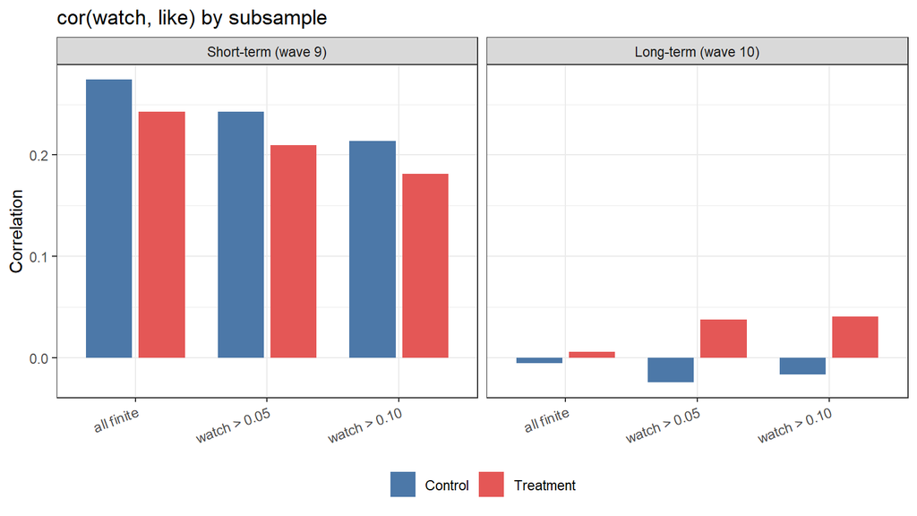

```r
ggplot(
  cor_tbl,
  aes(x = sample, y = cor_watch_like, fill = treatment)
) +
  geom_col(position = position_dodge(width = 0.8), width = 0.7) +
  scale_fill_manual(values = treat_cols) +
  facet_wrap(~horizon) +
  labs(
    title = "cor(watch, like) by subsample",
    x = NULL,
    y = "Correlation",
    fill = NULL
  ) +
  theme_bw(base_size = 11) +
  theme(
    axis.text.x = element_text(angle = 20, hjust = 1),
    legend.position = "bottom"
  )
```

# 9 Watch → like (row-level) mirrors analysis figure pipeline

Same filters as `prep_watch_like` in `2_analysis.qmd` (finite watch + like; article strategies).

```r
df_wl <- df |> filter(is.finite(watch), is.finite(like))

means_wl <- df_wl |>
  summarise(
    watch = mean(watch),
    like = mean(like),
    n = n(),
    .by = c(horizon, strategy, treatment)
  )

means_wl |>
  mutate(across(where(is.numeric), ~ round(.x, 4))) |>
  kable(caption = "Panel means for watch → like (same sample as analysis figure).")
```

Panel means for watch → like (same sample as analysis figure).

[output not shown]

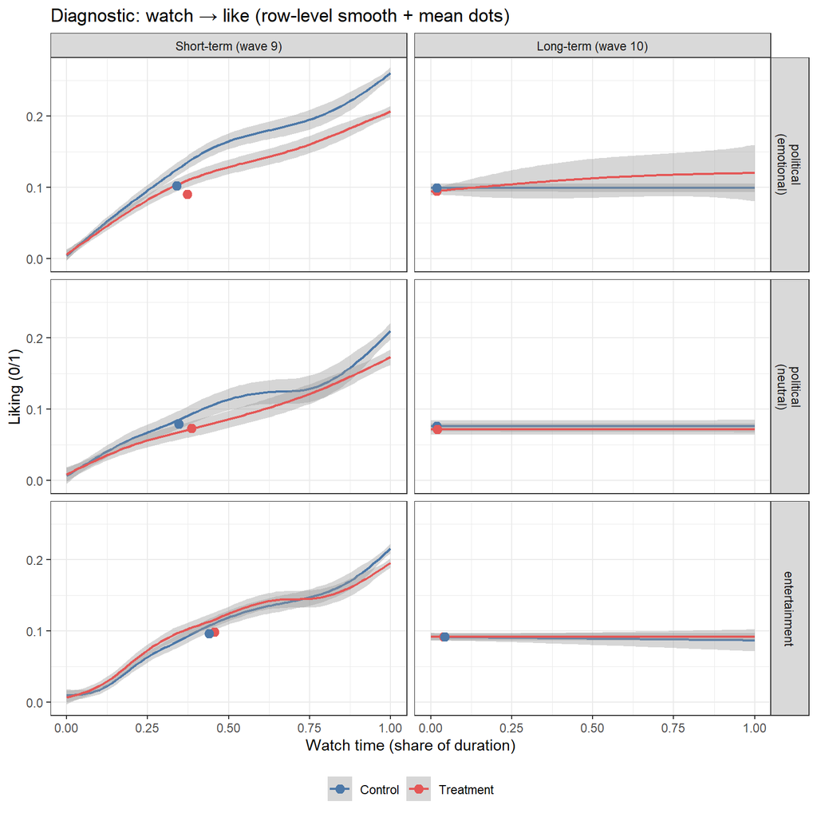

```r
ggplot(df_wl, aes(x = watch, y = like, color = treatment)) +
  geom_smooth(se = TRUE, linewidth = 0.8) +
  geom_point(
    data = means_wl,
    aes(fill = treatment),
    shape = 21,
    size = 2.6,
    stroke = 0.6
  ) +
  scale_color_manual(values = treat_cols) +
  scale_fill_manual(values = treat_cols) +
  facet_grid(rows = vars(strategy), cols = vars(horizon)) +
  labs(
    title = "Diagnostic: watch → like (row-level smooth + mean dots)",
    x = "Watch time (share of duration)",
    y = "Liking (0/1)",
    color = NULL,
    fill = NULL
  ) +
  theme_bw(base_size = 11) +
  theme(legend.position = "bottom")
```

# 10 Optional: wave 10, watch > 0.1 — binned means and lm

```r
df_w10_hi <- df |>
  filter(
    horizon == "Long-term (wave 10)",
    is.finite(watch),
    is.finite(like),
    watch > 0.1
  )

cat(
  "Wave 10 rows with watch > 0.1 and finite like: ",
  nrow(df_w10_hi),
  " (unique IDs: ", n_distinct(df_w10_hi$ID), ")\n",
  sep = ""
)
```

```
Wave 10 rows with watch > 0.1 and finite like: 2801 (unique IDs: 973)
```

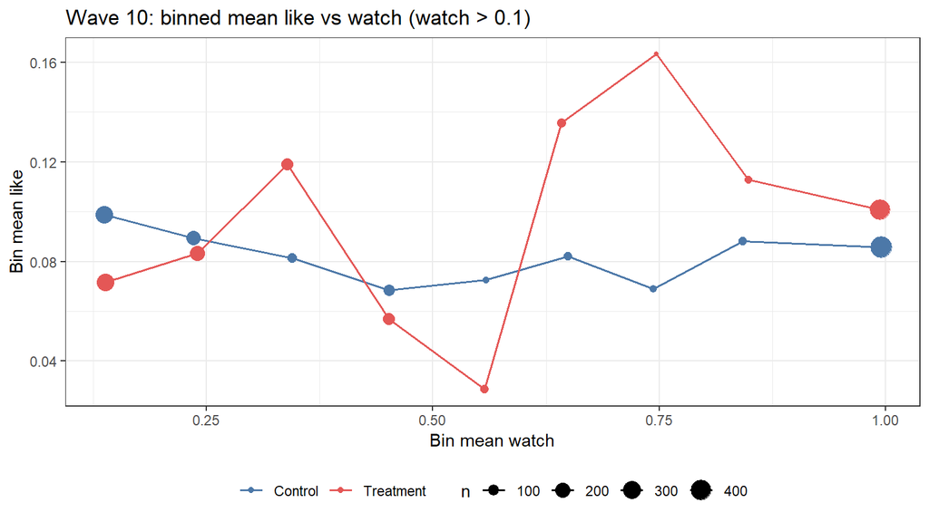

```
Call:
lm(formula = like ~ watch * treatment, data = df_w10_hi)

Residuals:
     Min       1Q   Median       3Q      Max
-0.10667 -0.09170 -0.08535 -0.08042  0.92397

Coefficients:
                         Estimate Std. Error t value Pr(>|t|)
(Intercept)               0.09358    0.01465   6.390 1.94e-10 ***
watch                    -0.01316    0.02162  -0.609    0.543
treatmentTreatment       -0.02096    0.02043  -1.026    0.305
watch:treatmentTreatment  0.04721    0.03100   1.523    0.128
---
Signif. codes:  0 '***' 0.001 '**' 0.01 '*' 0.05 '.' 0.1 ' ' 1

Residual standard error: 0.2841 on 2797 degrees of freedom
Multiple R-squared:  0.001053,  Adjusted R-squared:  -1.836e-05
F-statistic: 0.9829 on 3 and 2797 DF,  p-value: 0.3998
```

```r
if (nrow(df_w10_hi) >= 20) {
  binned <- df_w10_hi |>
    mutate(bin = cut(watch, breaks = seq(0.1, 1, by = 0.1), include.lowest = TRUE)) |>
    summarise(
      mean_like = mean(like),
      mean_watch = mean(watch),
      n = n(),
      .by = c(treatment, bin)
    )

  print(
    ggplot(binned, aes(x = mean_watch, y = mean_like, color = treatment, size = n)) +
      geom_point() +
      geom_line(aes(group = treatment), linewidth = 0.6) +
      scale_color_manual(values = treat_cols) +
      labs(
        title = "Wave 10: binned mean like vs watch (watch > 0.1)",
        x = "Bin mean watch",
        y = "Bin mean like",
        color = NULL,
        size = "n"
      ) +
      theme_bw(base_size = 11) +
      theme(legend.position = "bottom")
  )

  fit <- lm(like ~ watch * treatment, data = df_w10_hi)
  print(summary(fit))
} else {
  cat("Too few wave-10 rows with watch > 0.1 for binned / lm diagnostics.\n")
}
```

# 11 Person-level mean watch: wave 9 vs wave 10

Unit = **respondent** (`ID`). x = person mean `watch_percentage_` in wave 9; y = person mean in wave 10; color / facets = treatment. Only IDs present in both prepared waves.

```r
person_watch <- function(dat) {
  dat |>
    transmute(
      ID = as.character(ID),
      treatment = factor(
        ifelse(workshop_Treatment == 1, "Treatment", "Control"),
        levels = c("Control", "Treatment")
      ),
      watch = as.numeric(watch_percentage_)
    ) |>
    summarise(
      n_videos = n(),
      n_finite = sum(is.finite(watch)),
      # all-NA → NA_real_ (avoid NaN from mean(..., na.rm = TRUE))
      mean_watch = {
        w <- watch[is.finite(watch)]
        if (length(w) > 0) mean(w) else NA_real_
      },
      .by = c(ID, treatment)
    )
}

pw9  <- person_watch(wave_9)  |>
  rename(mean_watch_w9 = mean_watch, n_videos_w9 = n_videos, n_finite_w9 = n_finite)
pw10 <- person_watch(wave_10) |>
  rename(mean_watch_w10 = mean_watch, n_videos_w10 = n_videos, n_finite_w10 = n_finite)

pw_all <- inner_join(pw9, pw10, by = c("ID", "treatment"))
# Scatter / cor use IDs with at least one finite watch in each wave
pw <- pw_all |>
  filter(is.finite(mean_watch_w9), is.finite(mean_watch_w10))

sum_pw <- pw_all |>
  summarise(
    n_id_both_waves = n(),
    n_id_finite_both = sum(is.finite(mean_watch_w9) & is.finite(mean_watch_w10)),
    n_id_allNA_w10 = sum(is.finite(mean_watch_w9) & !is.finite(mean_watch_w10)),
    mean_w9 = mean(mean_watch_w9, na.rm = TRUE),
    mean_w10 = mean(mean_watch_w10, na.rm = TRUE),
    cor_w9_w10 = cor(mean_watch_w9, mean_watch_w10, use = "complete.obs"),
    share_w10_near_w9 = mean(
      abs(mean_watch_w9 - mean_watch_w10) < 0.01,
      na.rm = TRUE
    ),
    .by = treatment
  )

sum_pw |>
  mutate(across(where(is.numeric), ~ round(.x, 4))) |>
  kable(caption = "Person-level mean watch by treatment (IDs in both waves). Cor/means use finite person-means only.")
```

Person-level mean watch by treatment (IDs in both waves). Cor/means use finite person-means only.

| treatment | n_id_both_waves | n_id_finite_both | n_id_allNA_w10 | mean_w9 | mean_w10 | cor_w9_w10 | share_w10_near_w9 |
| --- | --- | --- | --- | --- | --- | --- | --- |
| Treatment | 1578 | 729 | 849 | 0.5970 | 0.0299 | 0.0697 | 0.0014 |
| Control | 1578 | 715 | 863 | 0.5538 | 0.0310 | -0.0372 | 0.0028 |

```r
cat(
  "\nPooled (finite person-means both waves): n_id = ", nrow(pw),
  " of ", nrow(pw_all), " overlapping IDs",
  "; mean w9 = ", round(mean(pw$mean_watch_w9), 4),
  "; mean w10 = ", round(mean(pw$mean_watch_w10), 4),
  "; cor = ", round(cor(pw$mean_watch_w9, pw$mean_watch_w10), 4),
  "\n",
  sep = ""
)
```

```
Pooled (finite person-means both waves): n_id = 1444 of 3156 overlapping IDs; mean w9 = 0.5829; mean w10 = 0.0305; cor = 0.0184
```

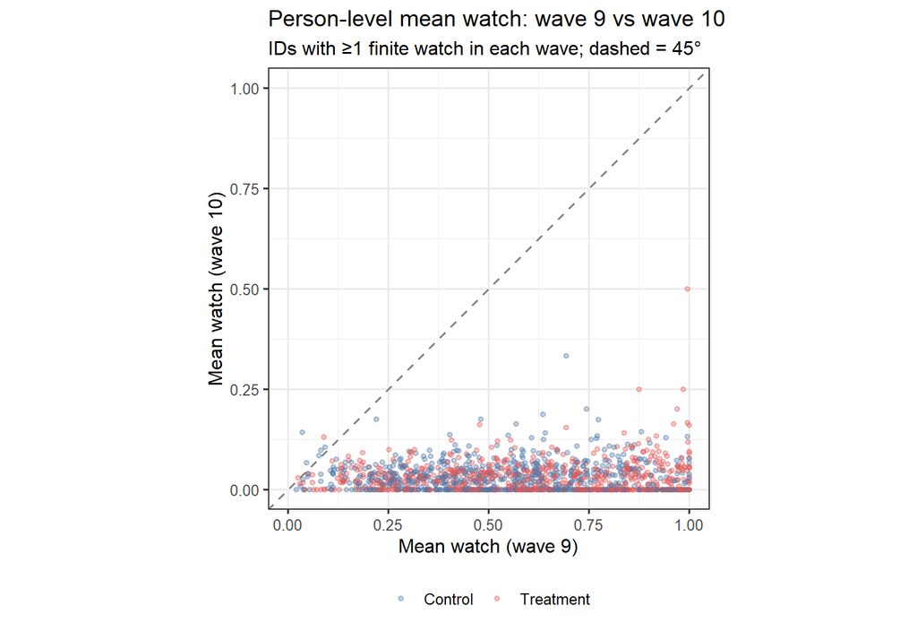

```r
ggplot(pw, aes(x = mean_watch_w9, y = mean_watch_w10, color = treatment)) +
  geom_abline(slope = 1, intercept = 0, linetype = "dashed", color = "grey50") +
  geom_point(alpha = 0.35, size = 1.2) +
  scale_color_manual(values = treat_cols) +
  coord_equal(xlim = c(0, 1), ylim = c(0, 1)) +
  labs(
    title = "Person-level mean watch: wave 9 vs wave 10",
    subtitle = "IDs with ≥1 finite watch in each wave; dashed = 45°",
    x = "Mean watch (wave 9)",
    y = "Mean watch (wave 10)",
    color = NULL
  ) +
  theme_bw(base_size = 12) +
  theme(legend.position = "bottom")
```

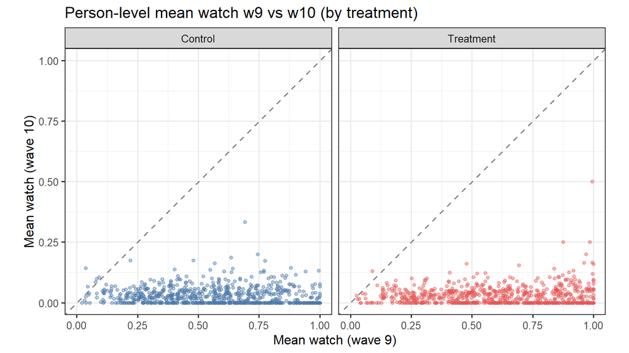

```r
ggplot(pw, aes(x = mean_watch_w9, y = mean_watch_w10, color = treatment)) +
  geom_abline(slope = 1, intercept = 0, linetype = "dashed", color = "grey50") +
  geom_point(alpha = 0.4, size = 1.2) +
  scale_color_manual(values = treat_cols) +
  facet_wrap(~treatment) +
  coord_equal(xlim = c(0, 1), ylim = c(0, 1)) +
  labs(
    title = "Person-level mean watch w9 vs w10 (by treatment)",
    x = "Mean watch (wave 9)",
    y = "Mean watch (wave 10)",
    color = NULL
  ) +
  theme_bw(base_size = 12) +
  theme(legend.position = "none")
```

# 12 Notes for figure verification

- **Columns:** short-term uses `data/wave_9.rds`; long-term uses `data/wave_10.rds`. Both expose `watch_percentage_` and `videoLikep1r` (same names).
- **Scale:** `watch_percentage_` ∈ [0, 1] = `watchtime_video_ / duration_video_` (identity in prepared data).
- **NA handling in figures:** `is.finite(watch)` drops NAs; no NA→0.
- **Near-zero long-term mean watch:** present in source Stata after the same `SwitchedToRandom == 1` and valid-duration filters as prep — not introduced by the ggplot pipeline. High skip / high share of exact zeros among non-missing watch in wave 10.
- **Not a wave-9→wave-10 join bug:** person-level cor(w9, w10) mean watch is near zero; levels do not match (see scatter above).